[figure not shown]

# Standard Euler and Located Euler Solution for Magnetic and Gravity Fields

## 1. Introduction

Geophysical methods, particularly magnetic and gravity surveys, are essential for subsurface exploration. Among various interpretation techniques, Euler deconvolution stands out for its ability to estimate the position and depth of subsurface sources. This blog discusses the **Standard Euler** and **Located Euler** solutions, commonly used for interpreting magnetic and gravity fields, highlighting their mathematical foundations, applications, and differences.

## 2. Euler Deconvolution Overview

Euler deconvolution is a mathematical technique used to interpret potential field data (gravity and magnetics) by estimating the location and depth of anomalous sources based on the gradient and field strength of measured data. It is a widely used technique because of its speed and effectiveness in detecting source locations, even from regional data.

## 3. Standard Euler Deconvolution

### 3.1 Mathematical Formulation

Euler deconvolution relies on Euler's homogeneity equation, which relates the spatial derivatives of a potential field to the source's location and a structural index (SI). The standard Euler equation for a potential field $ T(x, y, z) $ is given by:

$ (x - x_0) \frac{\partial T}{\partial x} + (y - y_0) \frac{\partial T}{\partial y} + (z - z_0) \frac{\partial T}{\partial z} = N(T - B) $

Where:

- $ (x_0, y_0, z_0) $ are the coordinates of the source,
- $ T $ is the potential field value,
- $ N $ is the structural index,
- $ B $ is the regional background field.

### 3.2 Application in Magnetic and Gravity Fields

Standard Euler deconvolution is extensively used in both magnetic and gravity fields to locate geological sources such as fault lines, mineral deposits, and other structural features. For magnetic data, it works with the total magnetic intensity (TMI) grid, while for gravity, it uses the Bouguer anomaly grid.

### 3.3 Advantages and Limitations

**Advantages**:

- Rapid computation across large datasets.
- Effective for identifying multiple sources simultaneously.

**Limitations**:

- Sensitive to noise in data.
- Requires accurate selection of the structural index (SI), which is often difficult without prior knowledge of source geometry.
- Assumes the sources are homogeneous and located at depth, which may not always be accurate for complex geological settings.

## 4. Located Euler Deconvolution

### 4.1 Concept and Need

The **Located Euler** deconvolution addresses some limitations of the Standard Euler by incorporating information about the location of known geological structures or additional constraints. This allows for a more precise estimation of the source parameters, especially in complex terrains where the assumptions of the standard approach may not hold.

### 4.2 Methodology

Located Euler combines the standard Euler formulation with additional location constraints, such as known geological boundaries or depth estimates from other methods. This hybrid approach helps in focusing on specific areas and improving the reliability of source depth and position estimates.

### 4.3 Application to Magnetic and Gravity Data

Located Euler is particularly useful in regions where known geological information exists, such as near mines or well-mapped fault zones. By refining the search area, it reduces ambiguity and provides better localization of subsurface anomalies.

### 4.4 Comparison with Standard Euler

- **Accuracy**: Located Euler generally provides more accurate results due to the additional constraints.
- **Flexibility**: Standard Euler is more flexible for large-scale regional surveys, while Located Euler is better for detailed, targeted investigations.
- **Complexity**: Located Euler requires more information (e.g., from other geophysical methods), making it more computationally intensive.

## 5. Conclusion

Both Standard Euler and Located Euler deconvolution techniques are valuable tools for interpreting magnetic and gravity data. While the Standard Euler method is fast and suitable for broad regional surveys, the Located Euler method offers greater accuracy in constrained environments. The choice of method depends on the specific geological context and the available data.

## 6. References

1. Reid, A.B., Allsop, J.M., Granser, H., Millett, A.J., & Somerton, I.W. (1990). Magnetic interpretation in three dimensions using Euler deconvolution. *Geophysics*, 55(1), 80-91.
2. Thompson, D.T. (1982). Euler: A new technique for making computer-assisted depth estimates from magnetic data. *Geophysics*, 47(1), 31-37.
3. Silva, J.B.C., & Barbosa, V.C.F. (2006). Gravity and magnetic interpretation in the framework of Euler deconvolution. *Geophysics*, 71(4), 63-71.
4. Nabighian, M.N. (1972). The analytic signal of two-dimensional magnetic bodies with polygonal cross-section: Its properties and use for automated anomaly interpretation. *Geophysics*, 37(3), 507-517.

## Part- I: Standard Euler Solution

```python
import numpy as np
import matplotlib.pyplot as plt
import pandas as pd
import Forward_Model as fm
import time
from tqdm import tqdm
import grav_mag_inv as gmi
import Grav_Mag_Transform as gt
import GravMagPro as gmp
import rasterio
import Euler_Deconvolution as ev
import seaborn as sns
```

```python
df = pd.read_csv('mag_data11.csv')
df.head()
```

|  | X | Y | Z | mag |
| --- | --- | --- | --- | --- |
| 0 | 330000 | 6629200 | 211.055369 | 5535 |
| 1 | 330050 | 6629200 | 210.654999 | 5500 |
| 2 | 330100 | 6629200 | 210.286555 | 5476 |
| 3 | 330150 | 6629200 | 209.952679 | 5479 |
| 4 | 330200 | 6629200 | 209.655742 | 5496 |

```python
# Calculate the midpoints of X and Y for the filtered data
x_mid = df['X'].mean()
y_mid = df['Y'].mean()

df['X_centered'] = df['X'] - x_mid
df['Y_centered'] = df['Y'] - y_mid

# Display the transformed dataset
print(df[['X_centered', 'Y_centered', 'mag']])
```

```
       X_centered  Y_centered   mag
0         -4500.0     -6900.0  5535
1         -4450.0     -6900.0  5500
2         -4400.0     -6900.0  5476
3         -4350.0     -6900.0  5479
4         -4300.0     -6900.0  5496
...           ...         ...   ...
12665      4300.0      6900.0  4945
12666      4350.0      6900.0  4943
12667      4400.0      6900.0  4940
12668      4450.0      6900.0  4938
12669      4500.0      6900.0  4936

[12670 rows x 3 columns]
```

```python
dt = df[
    (df['X_centered'] > -2000) & (df['X_centered'] < 2000) & (df['Y_centered'] > -4000) & (df['Y_centered'] < 4000)
].copy()
```

```python
mag_grid, x_grid, y_grid = ev.create_grid(dt, 201, 401)
```

```python
mag_grid = mag_grid - np.mean(mag_grid.mean())
target_points_x = 201
target_points_y = 401
```

```python
# Extracting data from DataFrame
x = dt['X'].values
y = dt['Y'].values
# Determine cell size based on the spacing of grid points
cell_size_x = (x.max() - x.min()) / (target_points_x - 1)
cell_size_y = (y.max() - y.min()) / (target_points_y - 1)

# Automatically determine the upper-left corner
upper_left_x = x.min()
upper_left_y = y.max()

# Create an affine transform for the grid (Y cell size is negative to go downward)
transform = rasterio.transform.from_origin(upper_left_x, upper_left_y, cell_size_x, -cell_size_y)
```

```python
# Optional parameters for the Grid class
nodata_value = -9999
name = 'OptimizedGrid'
filename = 'theoritical_grid.tif'
mask = None  # No mask for now
crs = None  # Set your CRS here
```

```python
data_array = mag_grid
dMx, dMy, dMz = ev.compute_derivatives(data_array, transform, nodata_value, name, filename, mask, crs = None)
```

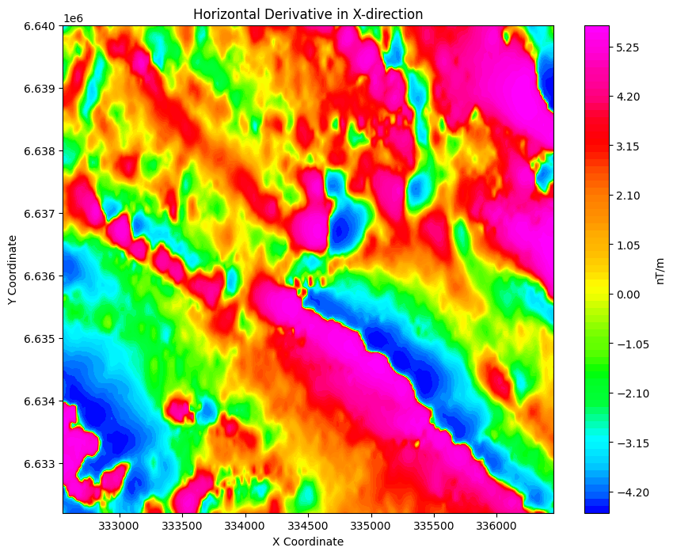

```python
ev.plot_contours(x_grid, y_grid, dMx, label = 'nT/m', title = 'Horizontal Derivative in X-direction')
```

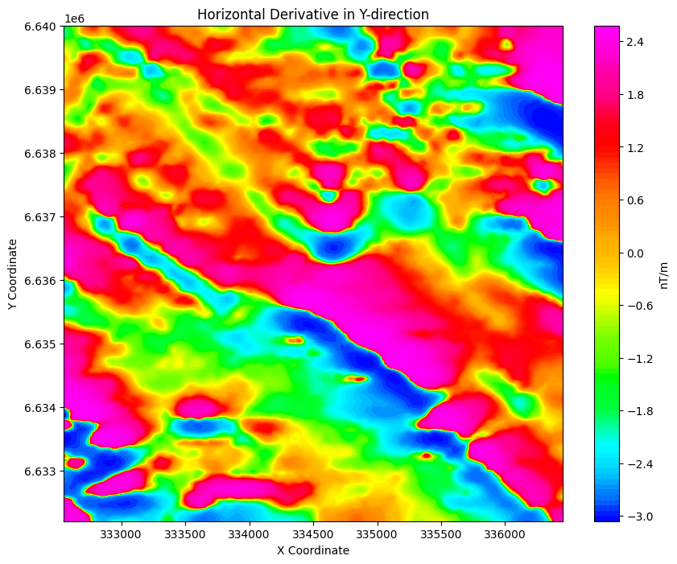

```python
ev.plot_contours(x_grid, y_grid, dMy, label = 'nT/m', title = 'Horizontal Derivative in Y-direction')
```

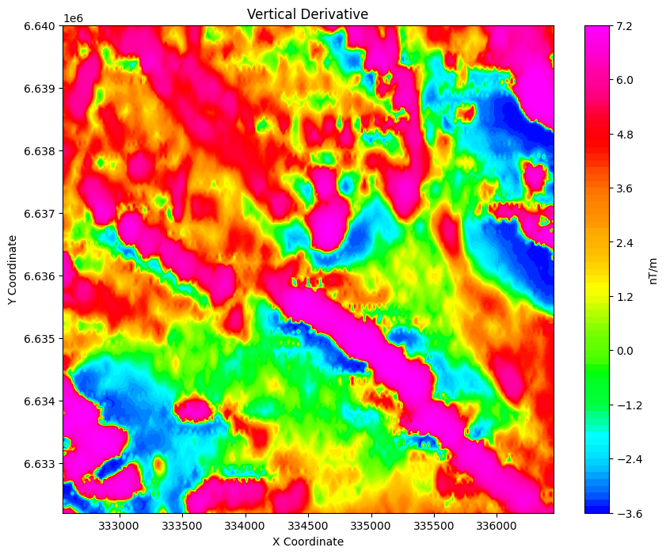

```python
ev.plot_contours(x_grid, y_grid, dMz, label = 'nT/m', title = 'Vertical Derivative')
```

```python
max_depth = 1000
window_size=5
slide_distance=1
structural_index=1
min_denominator=1e-8
```

```python
distance_threshold = 7000
residual_threshold = 20000
# Apply Euler Deconvolution using a sliding window in X and Y directions
structural_index = 1  # Example structural index
start_time = time.time()
solutions = ev.euler_deconvolution_3d_window_xy_real(dt, mag_grid, dMx, dMy, dMz, structural_index, window_size,
                                               distance_threshold, residual_threshold, cell_size_x=cell_size_x,
                                                     cell_size_y = cell_size_y)
elapsed_time = time.time() - start_time
print(f"Time taken: {elapsed_time:.2f} seconds")
```

```
Time taken: 12.27 seconds
```

```python
# Convert results to a DataFrame for easier visualization and further processing
solutions_df = pd.DataFrame(solutions)
```

```python
solutions_df.dropna(inplace=True)
solutions_df.head()
```

|  | x0 | y0 | z0 | window_x | window_y | x_offset | y_offset | residuals |
| --- | --- | --- | --- | --- | --- | --- | --- | --- |
| 0 | 332536.129115 | 6.632347e+06 | 6349.134635 | 332589.0 | 6632239.0 | -52.870885 | 107.702203 | 3635.130560 |
| 1 | 332556.309548 | 6.632352e+06 | 7020.405365 | 332608.5 | 6632239.0 | -52.190452 | 112.944032 | 11809.864446 |
| 2 | 332800.875973 | 6.632150e+06 | 3495.328886 | 332745.0 | 6632239.0 | 55.875973 | -88.674000 | 12628.247190 |
| 3 | 332807.060419 | 6.632172e+06 | 2486.284592 | 332764.5 | 6632239.0 | 42.560419 | -66.707814 | 6025.087020 |
| 4 | 332821.633441 | 6.632183e+06 | 1873.511849 | 332784.0 | 6632239.0 | 37.633441 | -56.168030 | 3890.874124 |

```python
solutions_df = solutions_df[(solutions_df['z0'] >=5) & (solutions_df['z0'] <=1000)]
solutions_df = solutions_df[solutions_df['residuals'] <=5]
solutions_df = solutions_df[(solutions_df['x_offset'] >= 14) & (solutions_df['x_offset'] <= 20)]
solutions_df = solutions_df[(solutions_df['y_offset'] >= -25) & (solutions_df['y_offset'] <= -15)]
```

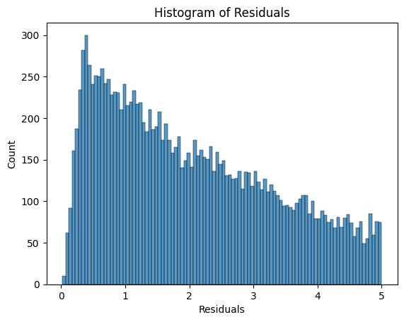

```python
sns.histplot(data=solutions_df, x='residuals', bins=100)
plt.xlabel('Residuals')
plt.ylabel('Count')
plt.title('Histogram of Residuals')
plt.show()
```

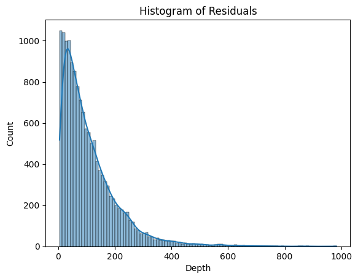

```python
sns.histplot(data=solutions_df, x='z0', bins=100, kde=True)
plt.xlabel('Depth')
plt.ylabel('Count')
plt.title('Histogram of Residuals')
plt.show()
```

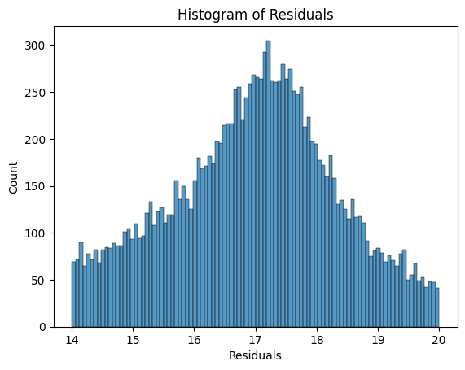

```python
sns.histplot(data=solutions_df, x='x_offset', bins=100)
plt.xlabel('Residuals')
plt.ylabel('Count')
plt.title('Histogram of Residuals')
plt.show()
```

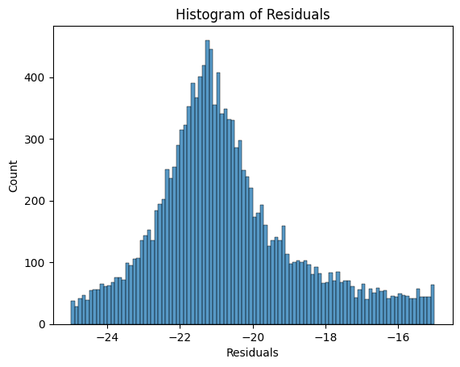

```python
sns.histplot(data=solutions_df, x='y_offset', bins=100)
plt.xlabel('Residuals')
plt.ylabel('Count')
plt.title('Histogram of Residuals')
plt.show()
```

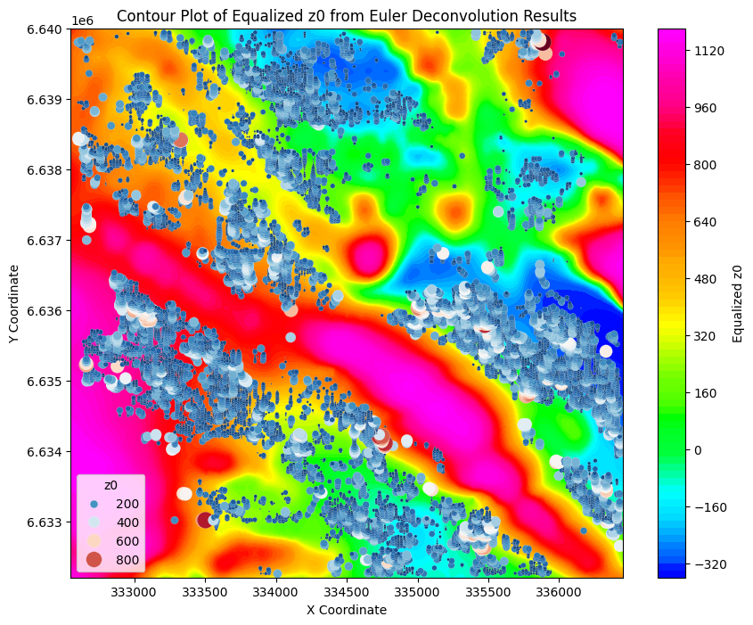

```python
ev.plot_results(solutions_df, mag_grid, x_grid, y_grid)
```

## Part- II: Located Euler Solution

```python
analytical = ev.calculate_analytical(dMx, dMy, dMz)
```

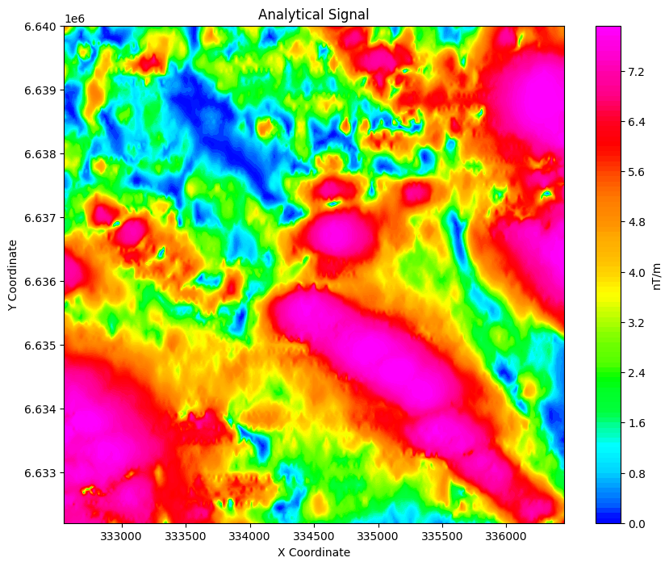

```python
ev.plot_contours(x_grid, y_grid, analytical, label = 'nT/m', title = 'Analytical Signal')
```

```python
peaks_df = ev.get_gird_peaks(analytical, x_grid, y_grid, distance_threshold =20, sigma =2, threshold=0.5, order=4)
```

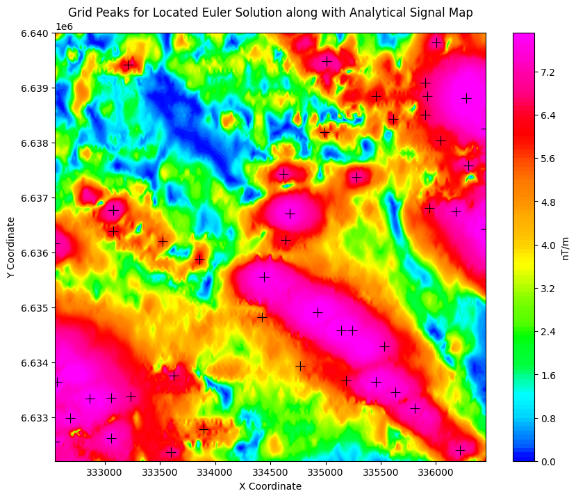

```python
ev.plot_peak(peaks_df, analytical, x_grid, y_grid)
```

```python
located_solutions = ev.located_euler_deconvolution_3d_window_xy_real(peaks_df, df, mag_grid, dMx, dMy, dMz,
                                              structural_index, window_size, distance_threshold,
                                              residual_threshold, cell_size_x=19.5, cell_size_y=39)
```

```python
# Convert results to a DataFrame for easier visualization and further processing
located_solutions_df = pd.DataFrame(located_solutions)
```

```python
located_solutions_df = located_solutions_df[located_solutions_df['z0']>0]
```

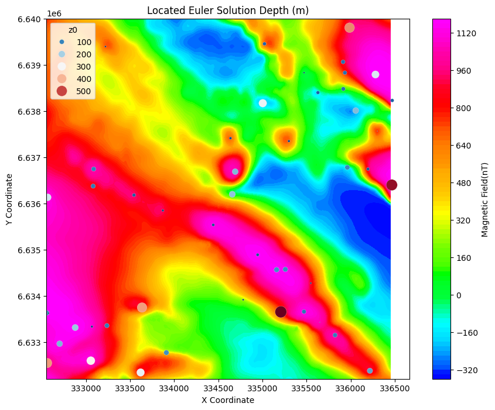

```python
ev.plot_results(located_solutions_df, mag_grid, x_grid, y_grid,
                label='Magnetic Field(nT)', title = 'Located Euler Solution Depth (m)')
```

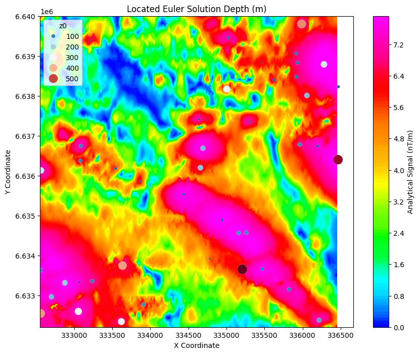

```python
ev.plot_results(located_solutions_df, analytical, x_grid, y_grid,
               label='Analytical Signal (nT/m)', title = 'Located Euler Solution Depth (m)')
```